# Prosper Loan Analysis

## by Akinyemi Akinbode

## Investigation Overview

> In this investigation, I am interested in finding out relationships among different variables as found in the dataset.

> I am also interested in discovering the best variable in predicting deliquency

## Dataset Overview

> The dataset contains peer-to-peer loan information of approximately 113,000 loans from Prosper Funding LLC.

> The major attributes analysed include:

> Combined Credit Grade, Income RangeBorrower, APRBorrower Rates, Amount Delinquent,Current Deliquencies, Employment Status, Listing Category, Loan Original Amount and Term

## Distribution of Loan Amount

> It is evident from the distribution that most of the loans taken is rightly skewed. Using the distplot function with more bins showed that the loans are usually round figures as evident in spikes on 5,000 10,000 , 15,000 and so on.

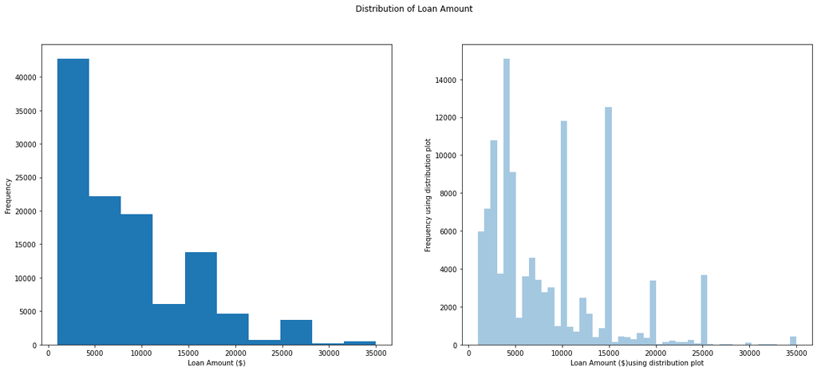

## Distribution of Credit Grades

> The distribution is unimodal and skewed to the right. It is interesting to see that there are more borrowers who are termed high risk than people with excellent credit grade

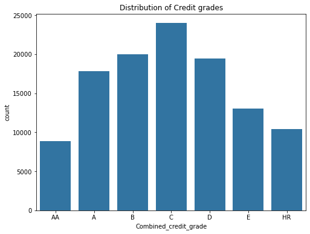

## Distribution of Current Delinquencies

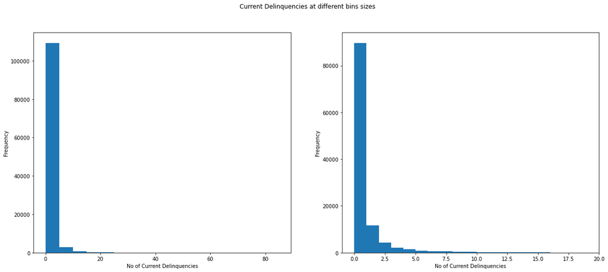

## Plot to investigate relationship between numeric variables

> It is worth noting that most of our numeric variables seem to not have much correlation contrary to what was suspected before the analysis. The only visible positive correlation are betweeen Borrower Rate and Borrower APR which are almost the same thing with the exception of the fees

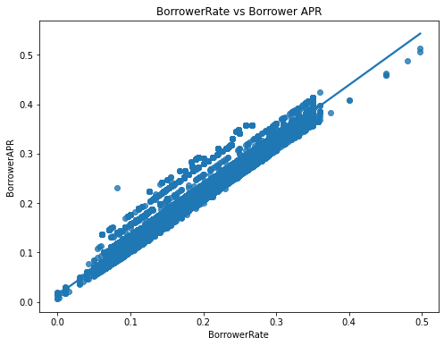

## Credit Grade against Count and Amount of Deliquencies

> Bar chart shows that Deliquency increases across the credit grades from Excellent credit score to high risk in terms of count and amount

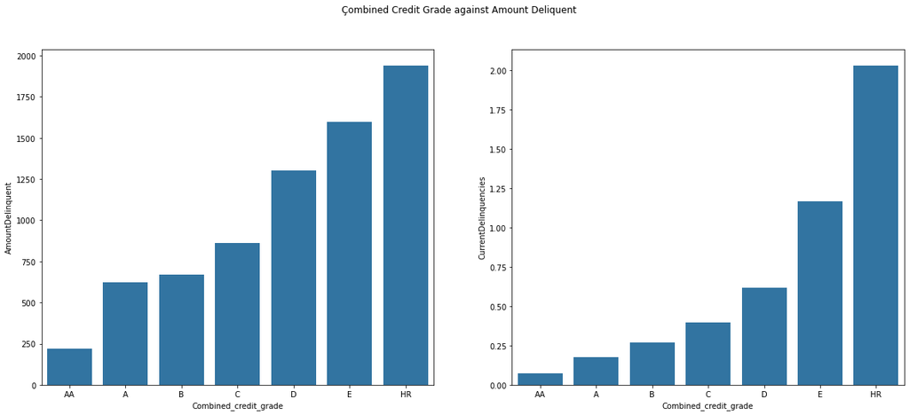

## Income Grade against Count and Amount of Deliquencies

> There seem to be a relationshipbetween high income range and amount of delinquent loans. However, for the no of current deliquencies, borrowers in the lower end of income tend to have more delinquencies than people in the high income range.

> This means despite the fact that low income earners are more likely to have delinquent facilities compared to their high income counterparts, the volume of the amount of the high earners is bigger.

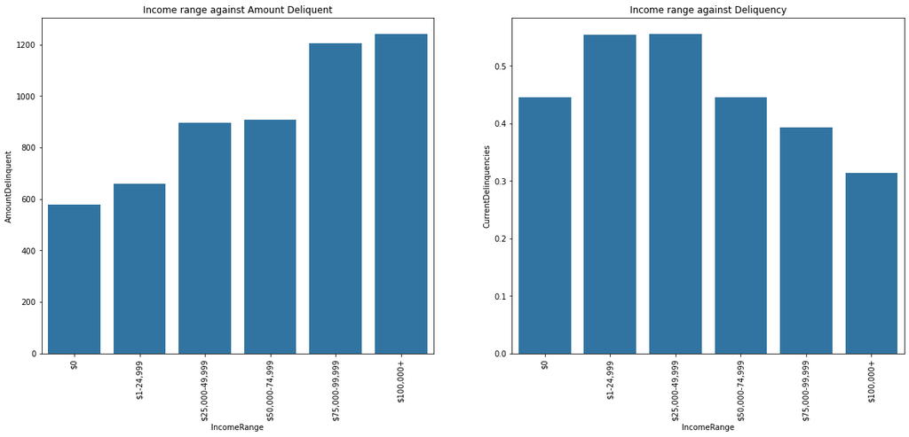

## Count of Income Range vs Credit Grade

> Having an income of $75k+ doesn't automatically guarantee the best crediratings.

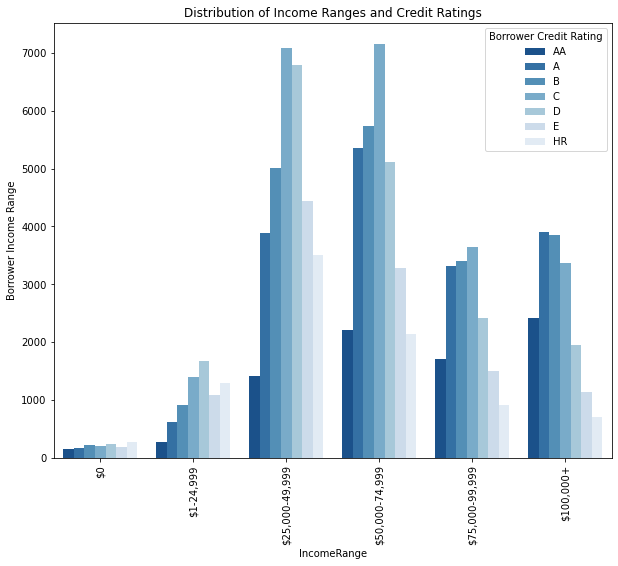

## Average count of deliquencies across Credit Rating and Income Range

> From the heat map we continue to see the trend of lower credit ratings leading to high count of deliquencies . It's interesting to see that the income range does not play a big influence on the count of deliquencies as the average count of deliquencies is higher in the 25k-50k range than in borrowers who earn no income.

> Income range does not seem to matter with no of deliquencies except for borrowers with bad credit ratings.

> This shows us that a better predictor of deliquencies is using credit grade rather than the relationship between the numeric variables.

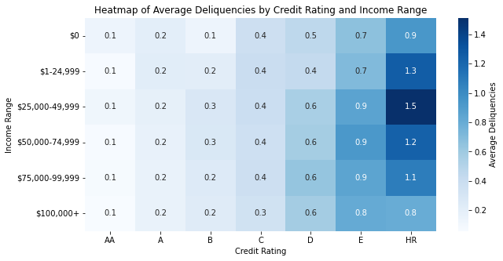